# Generation Forecasting

## Climate Data, Models, and Methods Used for Impact Analysis of Electricity Generation Systems (EGSs)

The analysis of climate change (CC) impacts on electricity generation systems (EGSs) is not straightforward. It follows several steps, including the acquisition, emission scenarios selection, preparation of appropriate climate data, and model investigations for CC impact analysis on the EGS. Climate data can be collected from many sources, including the most common platform, the Coupled Model Intercomparison Project (CMIP) ((**plaga_methods_2023?**)). The CMIP has different release versions, including CMIP3, CMIP5, and CMIP6. The climate projections vary according to the greenhouse gas (GHG) emission scenario, which depicts the influence of anthropogenic climate change. The most common scenarios used to investigate CC impacts on EGSs are A2 (most pessimistic), A1B (moderate), and B1 (most optimistic) from CMIP3, RCP2.6 (low emission), RCP4.5 (medium emission), and RCP8.5 (high emission) from CMIP5, and SSP1-2.6 (low emission), SSP2-4.5 (moderate), SSP3-7.0 (high emission with limited economic growth), and SSP5-8.5 (high emission with strong economic growth) from CMIP6. Depending on the purpose of the analysis, various scenario projections are used for evaluating climate change. Table 1 presents a summary of climate data, their downscaling and bias correction methods, and the methods utilized for CC impacts on different types of EGSs.

### Downscaling and bias-correction methods

Climate data are obtained from global circulation models (GCMs). These models provide climate projections with a coarse spatial resolution (e.g., 100 km x 100 km), which is impractical for CC impact analysis on EGSs at the regional to local scale. Therefore, it is required to downscale the GCMs’ projections to at least the regional scale. Statistical and dynamic downscaling are the two most common methods for spatially downscaling the projections of GCMs. In most cases, statistical downscaling methods are applied to obtain desired finer-resolution climate variables. These methods are based on statistical or empirical relationships and require less computational effort than dynamic methods (Plaga and Bertsch 2023). In recent years, machine learning methods (e.g., RFQ and QRF) have been utilized for statistical downscaling of hydro-meteorological variables from CMIP6 (Zhang et al. 2022). On the other hand, dynamic downscaling has a complex design structure and a huge computational demand. This type of downscaling is embedded in regional climate models (RCMs) that utilize GCM outputs and lateral boundary conditions to generate regional-scale climate variable projections (Zhang et al. 2022). Some climate data providers have established methods that can simultaneously bias correct and spatially disaggregate climate data from GCMs. For example, the Bureau of Reclamation has developed a monthly bias-correction and spatial disaggregation (BCSD) method to downscale and bias correct the CMIP5-GCMs data (Turner et al. 2017). Some studies (see Table 1) have employed standalone bias correction methods that compare climate projections with observations in the reference period and generate coefficients to correct future predictions. This type of statistical method assumes stationarity; however, climate variable projections are nonstationary, and that could add additional uncertainty (Plaga and Bertsch 2023). A good comparison between statistical and dynamic downscaling methods in terms of their strength and weaknesses is provided in the study of Wilby et al. (2002).

**Table 1.** Climate data, downscaling, and bias correction methods are employed for analyzing the impact of climate change on electricity generation systems.

| Reference | Generation Type | Climate Data | Downscaling Method | Bias-correction Method |
| --- | --- | --- | --- | --- |
| (van Vliet et al. 2012, 2013) | Thermal energy | - Designed A2 and B1 global emissions scenarios (3 GCMs: ECHAM5/MPIOM, CNRM-CM3 and IPSL-CM4) - Temporal resolution: daily | No downscaling | A fitted histogram equalization function proposed by Piani et al. (2010) |
| (Golombek et al. 2012) | Hydropower and Thermal energy | - 20 GCMs, two IPCC scenarios of A1B (HadCM3 and ECHAM5) -Only temperature variable | Empirical-statistical based on multiple regression proposed by Benestad (2005) | No bias correction |
| (Haguma et al. 2014) | Hydropower | - CMIP3-13 GCMs and 3 GHG (A1B, A2, and B1) -Temporal resolution: monthly | Statistical: based on singular value decomposition proposed by Widmann et al. (2003) | No bias correction |
| (Shrestha et al. 2014) | Hydropower | - HadCM3 GCMs (A2 and B2 scenarios) | Statistical: a decision support tool proposed by Wilby et al. (2002) | No bias correction |
| (Totschnig et al. 2017) | Mix | -3 RCM-ARPEGE (RegCM3, Remo model, and Aladin), A1B-scenarios - Temporal resolution: monthly average - Spatial resolution: 1 x 1 km | Dynamic | Gaussian distributed random error proposed by Haylock et al. (2008) |
| (Turner et al. 2017) | Hydropower | - CMIP5 from the Bureau of Reclamation, two scenarios RCP8.5 and RCP4.5 (16 GCM realizations) - Temporal resolution: monthly - Spatial resolution: 0.5° x 0.5° | Statistical: monthly bias-correction and spatial disaggregation (BCSD) | Statistical |
| (Ali et al. 2018) | Hydropower | - CMIP5-10 GCMs (GFDL-CM3, GFDL-ESM2G, GFDL-ESM2M, MIROC5, MIROC-ESM, MIROC-ESM-CHEM, NorESM1-M, CCSM4, CESM1-CAM5, and HadGEM2-AO), RCP2.6 and RCP8.5 scenarios | No downscaling | A trend-preserving statistical bias correction proposed by (Hempel et al. 2013) |
| (Kim et al. 2022) | Hydropower | - CMIP5-19 climate simulations from 14 GCMs and 2 RCPs (4.5 & 8.5) - 154 simulations (selected using k-means clustering) | No downscaling | Quantile-mapping method proposed by Mpelasoka and Chiew (2009) |
| (Zhang et al. 2022) | Hydro-Wind-Solar energy | - CMIP6-GCMs (CNRM-ESM2-1, MIROC6, and MRI-ESM2-0), RCPs and SSPs - Temporal resolution: hourly | Statistical: Machine learning based Random Forest Regressor and Quantile Regression Forest | No bias correction |
| (Li 2023) | Wind energy | - 15 RCMs (CanRCM4, RCP8.5) - Temporal resolution: mean hourly wind speed - Spatial resolution: 0.44° x 0.44° | Dynamic | No bias correction |
| Guo et al. (2023) | Hydropower | - CMIP5- 18 GCMs-3RCPs (2.6, 4.5, 8.5) - CMIP6- 17 GCMs-3SSPs (126, 245, 585) - Temporal resolution: monthly | Statistical: A sonographic mapping system (SYMAP) interpolation proposed by Shepard (1984) | A bias correction method proposed by Thrasher et al. (2012) |

### Methods for electricity generation prediction for the future period

#### Hydropower

In general, downscaled and bias-corrected climate variables (e.g., precipitation and temperatures) from different scenarios are forced into hydrologic models to investigate the hydrologic regime and to generate future flow conditions. These flows are then used as input to hydropower potential estimation models. The distribution of the estimated electricity is compared with the historical observation to analyze the impact of climate change on generation. In literature, a quite good range of hydropower potential station models or methods, including empirical formula (Parkinson and Djilali 2015), reservoir optimization algorithm-Sampling Stochastic Dynamic Programming (SSDP) (Haguma et al. 2014), WEAP (Boehlert et al. 2016) and MODSIM (Kim et al. 2022), have been used. One representative example of an empirical method is represented by equation 1.
$$E=ρghQ\tag{1}$$
In equation 1, E is the hydropower potential with projected streamflow Q at a hydraulic head h. ρ and g are the density of water and gravitational acceleration.

Reservoir optimization algorithms (ROAs) are used to determine operation rules or policies that include an average release from hydropower dams and energy production. The projected inflow simulations from the hydrologic model are fed to the ROA to determine operating policies under future climatic conditions obtained from different emission scenarios. Then they are compared with the baseline period policy in order to determine the impact of climate change on hydropower generation.

## Climate Data, Models, and Methods Used for Impact Analysis of Electricity Generation Systems (EGSs)

The analysis of climate change (CC) impacts on electricity generation systems (EGSs) is not straightforward. It follows several steps (see **Figure 1**), including the acquisition, emission scenarios selection, preparation of appropriate climate data, and model investigations for CC impact analysis on the EGS. Climate data can be collected from many sources, including the most common platform, the Coupled Model Intercomparison Project (CMIP) ((**plaga_methods_2023?**)). The CMIP has different release versions, including CMIP3, CMIP5, and CMIP6. The climate projections vary according to the greenhouse gas (GHG) emission scenario, which depicts the influence of anthropogenic climate change. The most common scenarios used to investigate CC impacts on EGSs are A2 (most pessimistic), A1B (moderate), and B1 (most optimistic) from CMIP3, RCP2.6 (low emission), RCP4.5 (medium emission), and RCP8.5 (high emission) from CMIP5, and SSP1-2.6 (low emission), SSP2-4.5 (moderate), SSP3-7.0 (high emission with limited economic growth), and SSP5-8.5 (high emission with strong economic growth) from CMIP6. Depending on the purpose of the analysis, various scenario projections are used for evaluating climate change. **Table 1** presents a summary of climate data, their downscaling and bias correction methods, and the methods utilized for CC impacts on different types of EGSs.

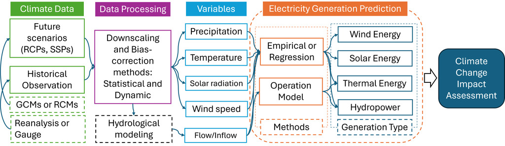

**Figure 1.** Process flow diagram of climate change impact assessment for electricity generation systems.

### Downscaling and bias-correction methods

Climate data are obtained from global circulation models (GCMs). These models provide climate projections with a coarse spatial resolution (e.g., 100 km x 100 km), which is impractical for CC impact analysis on EGSs at the regional to local scale. Therefore, it is required to downscale the GCMs’ projections to at least the regional scale. Statistical and dynamic downscaling are the two most common methods for spatially downscaling the projections of GCMs. In most cases, statistical downscaling methods are applied to obtain desired finer-resolution climate variables. These methods are based on statistical or empirical relationships and require less computational effort than dynamic methods ((**plaga_methods_2023?**)). In recent years, machine learning methods (e.g., RFQ and QRF) have been utilized for statistical downscaling of hydro-meteorological variables from CMIP6 ((**zhang_assessment_2022?**)). On the other hand, dynamic downscaling has a complex design structure and a huge computational demand. This type of downscaling is embedded in regional climate models (RCMs) that utilize GCM outputs and lateral boundary conditions to generate regional-scale climate variable projections ((**zhang_assessment_2022?**)). Some climate data providers have established methods that can simultaneously bias correct and spatially disaggregate climate data from GCMs. For example, the Bureau of Reclamation has developed a monthly bias-correction and spatial disaggregation (BCSD) method to downscale and bias correct the CMIP5-GCMs data ((**turner_climate_2017?**)). Some studies (see **Table 1**) have employed standalone bias correction methods that compare climate projections with observations in the reference period and generate coefficients to correct future predictions. This type of statistical method assumes stationarity; however, climate variable projections are nonstationary, and that could add additional uncertainty ((**plaga_methods_2023?**)). A good comparison between statistical and dynamic downscaling methods in terms of their strength and weaknesses is provided in the study of Wilby et al.((**wilby_sdsm_2002?**)).

**Table 1.** Climate data, downscaling, and bias correction methods are employed for analyzing the impact of climate change on electricity generation systems.

[output not shown]

### Methods for electricity generation prediction for the future period

#### Hydropower

In general, downscaled and bias-corrected climate variables (e.g., precipitation and temperatures) from different scenarios are forced into hydrologic models to investigate the hydrologic regime and to generate future flow conditions. These flows are then used as input to hydropower potential estimation models. The distribution of the estimated electricity is compared with the historical observation to analyze the impact of climate change on generation. In literature, a quite good range of hydropower potential station models or methods, including empirical formula ((**parkinson_robust_2015?**)), reservoir optimization algorithm-Sampling Stochastic Dynamic Programming (SSDP) ((**haguma_optimal_2014?**)), WEAP ((**boehlert_climate_2016?**)) and MODSIM ((**kim_climate_2022?**)), have been used. One representative example of an empirical method is represented by **equation 1**.
$$E=ρghQ\tag{1}$$
In **equation 1**, $E$ is the hydropower potential with projected streamflow $Q$ at a hydraulic head $h$. $ρ$ and $g$ are the density of water and gravitational acceleration.

Reservoir optimization algorithms (ROAs) are used to determine operation rules or policies that include an average release from hydropower dams and energy production. The projected inflow simulations from the hydrologic model are fed to the ROA to determine operating policies under future climatic conditions obtained from different emission scenarios. Then they are compared with the baseline period policy in order to determine the impact of climate change on hydropower generation.

Unlike the ROA, MODSIM, a complex surface water network system, can also be used to estimate hydropower generation. This model has an internal optimization operator that can allocate water based on physical and operational constraints. The inflow projection from hydrologic models is used as forcing for this MODSIM model to determine the hydropower generation potential for the future period and compared with the historical baseline period to identify the changes due to climate variability.

#### Wind Energy

The impact of climate change on future wind energy generation is generally estimated based on the operational wind speed at hub height. Under different emission scenarios (e.g., RCP8.5), future projections for wind speed at 10 m height from surface level are obtained from climate models (e.g., GCMs and RCMs) ((**yao_climate_2012?**), (**zhang_assessment_2022?**), (**li_impact_2023?**)). For wind turbine design, cut-in and cut-out wind speeds at hub height play a crucial role, and they typically range from 4 m/s to 25 m/s. Based on the design criteria, hub height varies from 50 m to 120 m, however, the average hub height in Canada is 83 m ((**cwtd_canadian_2022?**)). The wind speed at hub height is estimated using the following power-law relation (Equation 2) ((**yao_climate_2012?**), (**zhang_assessment_2022?**), (**plaga_methods_2023?**), (**li_impact_2023?**)).
$$\frac{V_H}{V_{10}} =(\frac{Z_H}{Z_{10}})^α\tag{2}$$

In **equation 2**, $V_H$ is the wind speed at hub height H ($Z_H$), and $V_{10}$ is the wind speed at 10 m height ($Z_{10}$). The exponent $α$ varies with the topographic terrain conditions, codes, and standards. For a natural, stable terrain profile, the $α$ value is 0.14 ((**yao_climate_2012?**), (**plaga_methods_2023?**), (**li_impact_2023?**)). The wind speed at hub height is then converted to wind energy by multiplying it by the wind energy density ((**li_impact_2023?**)).
$$W_E = \frac{1}{2} \rho A V_H^3 C_p \tag{3}$$

In **equation 3**, $W_E$ is the wind energy, ρ is the air density at hub height that varies with the temperature and wind profile, A is the cross-sectional area, and $C_p$ is the power coefficient. For climate change impact analysis, $W_E$ is simulated at each grid point or station, and then trend analysis is conducted. The t-test or the Mann-Kendell approach can be used for trend detection. In their study, Li ((**li_impact_2023?**)) utilized a t-test using a linear regression for trend detection. Another study ((**yao_climate_2012?**)) used the Weibull distribution for comparing wind production in the future period under different scenarios with reference to the period.

#### Solar Energy

Generally, photovoltaic (PV) solar cells are used for electricity (energy) generation. The generation capacity of PV can be expressed with the empirical formula (**equation 4**), consisting of solar radiation and temperature as independent variables ((**zhang_assessment_2022?**)). Therefore, two key climate variables, such as surface shortwave radiation (SSWR) and near-surface air temperature (NSAT), are used for the impact analysis of solar energy. The radiation impinging on each solar station is predicted to use SSWR, and the solar station’s ambient temperature is predicted from NSAT. Using historical data of these two variables, solar energy generation curves are produced by applying **equations 4** and **5**. Similar curves are developed for future projections and compared with the reference one developed with historical period data for impact analysis due to climate change.
$$C_F=(\frac{S_1}{S_2} )[1+λ_T (T_1-T_2)]\tag{4}$$
$$S_E=I_C.C_F.∆_τ\tag{5}$$
In **equations 4** and **5**, $C_F$ is the hourly capacity factor of the solar station, $S_1$ and $S_2$ are the solar radiation at the location of the solar station and under standard test conditions (ideal 1000 $W/m^2$), respectively. $T_1$ and $T_2$ are the temperatures at the location of the solar station and under standard test conditions, respectively, and $λ_T$ is the temperature coefficient (ideally negative). $S_E$ represents solar energy, $I_C$ is the installed capacity of the station, and $Δτ$ is the hours of period $τ$.

#### Thermal Energy (Nuclear, Natural Gas, Coal, and Biofuel)

Thermal energy encompasses the production of electricity by converting heat into power using nuclear, natural gas, coal, and biofuel sources. The impact of climate change on thermal energy production depends on the cooling systems used by each generation type. Typically, water and air flow (dry cooling) are used to cool down the generator. Therefore, water availability, water temperature, humidity, air pressure, and air temperature play a key role in the thermal power plant’s efficiency, which ultimately affects energy generation ((**lagace_assessing_2021?**)). Usually, two types of investigation are conducted to determine the impact of climate change on thermal energy systems: 1) regression analysis assuming linear dependency between air and water temperature, and 2) hydrologic modeling to calculate available water for cooling systems ((**plaga_methods_2023?**)).

In a study, Lagace ((**lagace_assessing_2021?**)) applied regression models to estimate climate impacts on thermal energy systems in Ontario. The models estimate the derated capacity of thermal systems, including those with recirculating cooling, dry cooling, once-through cooling, and combustion. These models are based on the air temperature, wet bulb air temperature, relative humidity, and air pressure, and were proposed by Bartos et al. ((**bartos_impacts_2016?**)), Henry and Pratson ((**henry_differentiating_2019?**)), and Craig et al. ((**craig_compounding_2020?**)). Like hydropower generation, hydrologic models are forced with future climate scenarios to simulate water flow. Then, the water management model (WMM) is applied to estimate the availability of cooling water under changing climatic conditions. To apply the WMM, a linear relationship is assumed between the available water and the water requirement for the plant’s cooling ((**plaga_methods_2023?**)).